# Prediction Exercise

Sovann Prey

4/17/2021

# Overview

This report will compare three classification models such as decision tree, random forest, and generalized boosted model on a datasets. The datasets come from devices such as Jawbone Up, Nike FuelBand, and Fitbit. These type of devices are part of the quantified self movement – a group of enthusiasts who take measurements about themselves regularly to improve their health, to find patterns in their behavior, or because they are tech geeks. The datasets are obtained from from accelerometers on the belt, forearm, arm, and dumbbell of 6 participants. They were asked to perform barbell lifts correctly and incorrectly in 5 different ways. The goal of your project is to predict the manner in which they did the exercise. This is the “classe” variable in the training set.

Reference: http://web.archive.org/web/20161224072740/http:/groupware.les.inf.puc-rio.br/har

# Data Loading and Processing

```r
library(lattice)
library(ggplot2)
library(caret)
library(kernlab)
library(rattle)
library(corrplot)
library(rpart)
library(rpart.plot)
library(e1071)
library(randomForest)
library(gbm)
set.seed(1980)

# Load training datasets
trainDs <- read.csv("./Data/pml-training.csv")

# Load testing datasets as validating datasets
validateDs <- read.csv("./Data/pml-testing.csv")


# Checking training datasets
dim(trainDs)
```

```
## [1] 19622   160
```

```r
# Checking validating datasets
dim(validateDs)
```

```
## [1]  20 160
```

There are 19622 observations and 160 variables in the training datasets; while 20 observations and 160 variables in the validating datasets.

Removing variables containing N/A and reducing irrelevant variables from training datasets.

```r
# Removing N/A
trainDs <- trainDs[, colSums(is.na(trainDs)) == 0]
validateDs <- validateDs[, colSums(is.na(validateDs)) == 0]
# Removing irrelevant columns/variables
trainDs <- trainDs[, -c(1:7)]
validateDs <- validateDs[, -c(1:7)]
```

Removing near-zero-variance variables.

```r
nvz <- nearZeroVar(trainDs)
trainDs <- trainDs[, -nvz]
dim(trainDs)
```

```
## [1] 19622    53
```

Splitting the training datasets into validation and training datasets.

```r
train <- createDataPartition(y=trainDs$classe, p=0.7, list=FALSE)
trainDs_new <- trainDs[train,]
testDs <- trainDs[-train,]
dim(trainDs_new)
```

```
## [1] 13737    53
```

```r
dim(testDs)
```

```
## [1] 5885   53
```

# Model Building and Comparision

Checking the highly correlated predictors/variables.

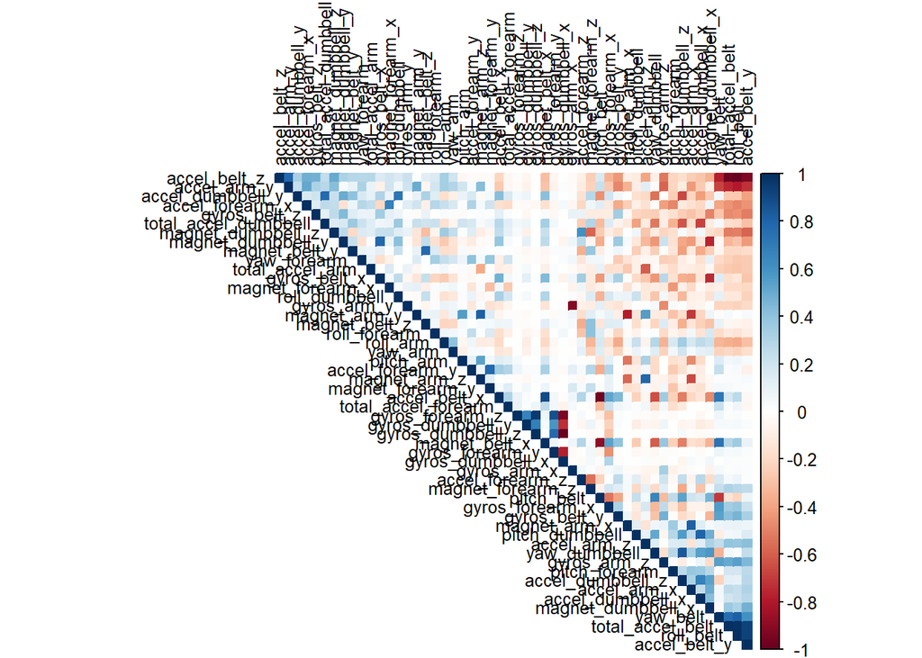

```r
cor_matrix <- cor(trainDs_new[, -53])
corrplot(cor_matrix, order = "FPC", method = "color", type = "upper",
         tl.cex = 0.8, tl.col = rgb(0, 0, 0))
```

The highly correlated preditors/variables are those with a dark color intersection. The name of the predictors/variables are followed (having the cutoff of 0.75).

```r
highlyCorrelated = findCorrelation(cor_matrix, cutoff=0.75)
names(trainDs_new)[highlyCorrelated]
```

```
##  [1] "accel_belt_z"      "roll_belt"         "accel_belt_y"
##  [4] "accel_arm_y"       "total_accel_belt"  "accel_dumbbell_z"
##  [7] "accel_belt_x"      "pitch_belt"        "magnet_dumbbell_x"
## [10] "accel_dumbbell_y"  "magnet_dumbbell_y" "accel_arm_x"
## [13] "accel_dumbbell_x"  "accel_arm_z"       "magnet_arm_y"
## [16] "magnet_belt_z"     "accel_forearm_y"   "gyros_forearm_y"
## [19] "gyros_dumbbell_x"  "gyros_dumbbell_z"  "gyros_arm_x"
```

Three models are used for prediction include decision trees, random forest, and generalized boosted model.

## Decision Trees

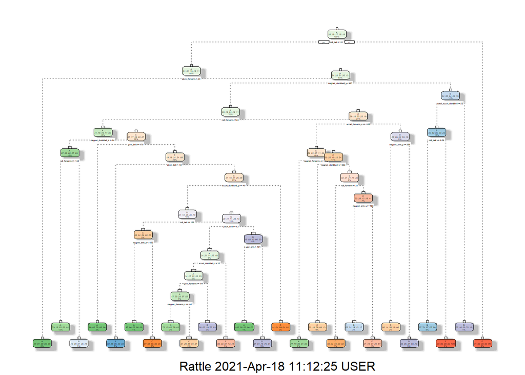

```r
decisionTreeModel <- rpart(classe ~ ., data=trainDs_new, method="class")
fancyRpartPlot(decisionTreeModel)
```

Checking the accuracy of the decision tree model using the testing datasets.

```r
predictDecisionTreeModel <- predict(decisionTreeModel, testDs, type = "class")
cm_decisionTreeModel <- confusionMatrix(predictDecisionTreeModel, factor(testDs$classe))
cm_decisionTreeModel
```

```
## Confusion Matrix and Statistics
##
##           Reference
## Prediction    A    B    C    D    E
##          A 1534  165   19   48   12
##          B   67  629  107  100  107
##          C   47  165  814   92   77
##          D   20   79   69  649   80
##          E    6  101   17   75  806
##
## Overall Statistics
##
##                Accuracy : 0.7531
##                  95% CI : (0.7419, 0.7641)
##     No Information Rate : 0.2845
##     P-Value [Acc > NIR] : < 2.2e-16
##
##                   Kappa : 0.6871
##
##  Mcnemar's Test P-Value : < 2.2e-16
##
## Statistics by Class:
##
##                      Class: A Class: B Class: C Class: D Class: E
## Sensitivity            0.9164   0.5522   0.7934   0.6732   0.7449
## Specificity            0.9421   0.9197   0.9216   0.9496   0.9586
## Pos Pred Value         0.8628   0.6228   0.6812   0.7235   0.8020
## Neg Pred Value         0.9659   0.8954   0.9548   0.9368   0.9434
## Prevalence             0.2845   0.1935   0.1743   0.1638   0.1839
## Detection Rate         0.2607   0.1069   0.1383   0.1103   0.1370
## Detection Prevalence   0.3021   0.1716   0.2031   0.1524   0.1708
## Balanced Accuracy      0.9292   0.7360   0.8575   0.8114   0.8517
```

## Random Forests

```r
controlRF <- trainControl(method="cv", number=3, verboseIter=FALSE)
randomForestModel <- train(classe ~ ., data=trainDs_new, method="rf", trControl=controlRF)
randomForestModel$finalModel
```

```
##
## Call:
##  randomForest(x = x, y = y, mtry = param$mtry)
##                Type of random forest: classification
##                      Number of trees: 500
## No. of variables tried at each split: 2
##
##         OOB estimate of  error rate: 0.71%
## Confusion matrix:
##      A    B    C    D    E  class.error
## A 3903    2    1    0    0 0.0007680492
## B   12 2639    7    0    0 0.0071482318
## C    0   22 2374    0    0 0.0091819699
## D    0    0   38 2210    4 0.0186500888
## E    0    0    3    8 2514 0.0043564356
```

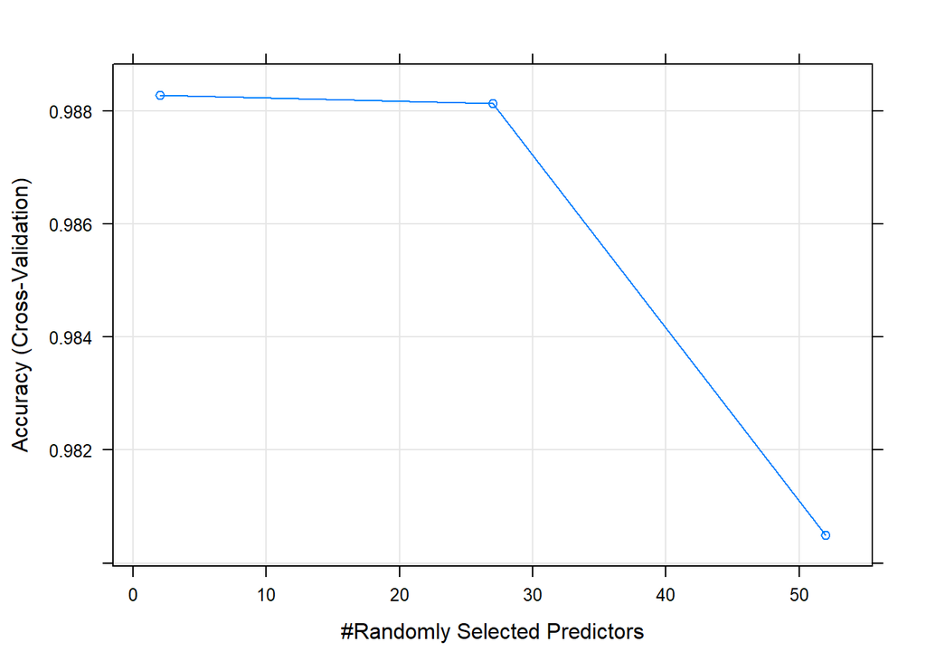

```r
plot(randomForestModel)
```

Checking the accuracy of the random forest model using the testing datasets.

```r
predictRandomForestModel <- predict(randomForestModel, newdata=testDs)
cm_randomForestModel <- confusionMatrix(predictRandomForestModel, factor(testDs$classe))
cm_randomForestModel
```

```
## Confusion Matrix and Statistics
##
##           Reference
## Prediction    A    B    C    D    E
##          A 1674   10    0    0    0
##          B    0 1123    8    0    0
##          C    0    6 1017   15    0
##          D    0    0    1  949    2
##          E    0    0    0    0 1080
##
## Overall Statistics
##
##                Accuracy : 0.9929
##                  95% CI : (0.9904, 0.9949)
##     No Information Rate : 0.2845
##     P-Value [Acc > NIR] : < 2.2e-16
##
##                   Kappa : 0.991
##
##  Mcnemar's Test P-Value : NA
##
## Statistics by Class:
##
##                      Class: A Class: B Class: C Class: D Class: E
## Sensitivity            1.0000   0.9860   0.9912   0.9844   0.9982
## Specificity            0.9976   0.9983   0.9957   0.9994   1.0000
## Pos Pred Value         0.9941   0.9929   0.9798   0.9968   1.0000
## Neg Pred Value         1.0000   0.9966   0.9981   0.9970   0.9996
## Prevalence             0.2845   0.1935   0.1743   0.1638   0.1839
## Detection Rate         0.2845   0.1908   0.1728   0.1613   0.1835
## Detection Prevalence   0.2862   0.1922   0.1764   0.1618   0.1835
## Balanced Accuracy      0.9988   0.9921   0.9935   0.9919   0.9991
```

## Generalized Boosted Model

```r
controlGBM <- trainControl(method = "repeatedcv", number = 5, repeats = 1)
generalizedBoostedModel  <- train(classe ~ ., data=trainDs_new, method = "gbm", trControl = controlGBM, verbose = FALSE)
generalizedBoostedModel$finalModel
```

```
## A gradient boosted model with multinomial loss function.
## 150 iterations were performed.
## There were 52 predictors of which 52 had non-zero influence.
```

```r
# print model summary
print(generalizedBoostedModel)
```

```
## Stochastic Gradient Boosting
##
## 13737 samples
##    52 predictor
##     5 classes: 'A', 'B', 'C', 'D', 'E'
##
## No pre-processing
## Resampling: Cross-Validated (5 fold, repeated 1 times)
## Summary of sample sizes: 10990, 10989, 10990, 10989, 10990
## Resampling results across tuning parameters:
##
##   interaction.depth  n.trees  Accuracy   Kappa
##   1                   50      0.7505276  0.6836466
##   1                  100      0.8201202  0.7724044
##   1                  150      0.8510590  0.8114987
##   2                   50      0.8548445  0.8160608
##   2                  100      0.9045639  0.8792145
##   2                  150      0.9304796  0.9120346
##   3                   50      0.8925531  0.8639586
##   3                  100      0.9416171  0.9261222
##   3                  150      0.9603987  0.9498963
##
## Tuning parameter 'shrinkage' was held constant at a value of 0.1
##
## Tuning parameter 'n.minobsinnode' was held constant at a value of 10
## Accuracy was used to select the optimal model using the largest value.
## The final values used for the model were n.trees = 150, interaction.depth =
##  3, shrinkage = 0.1 and n.minobsinnode = 10.
```

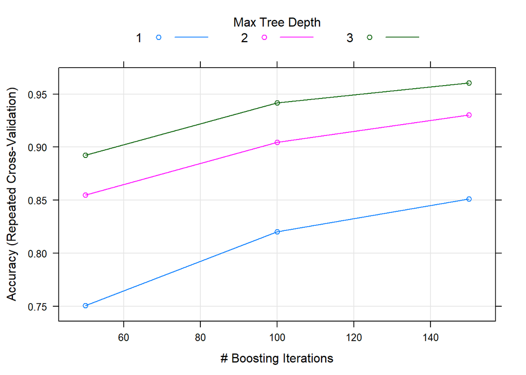

```r
plot(generalizedBoostedModel)
```

Checking the accuracy of the generalized boosted model using the testing datasets.

```r
predictGeneralizedBoostedModel <- predict(generalizedBoostedModel, newdata=testDs)
cm_generalizedBoostedModel <- confusionMatrix(predictGeneralizedBoostedModel, factor(testDs$classe))
cm_generalizedBoostedModel
```

```
## Confusion Matrix and Statistics
##
##           Reference
## Prediction    A    B    C    D    E
##          A 1658   42    0    1    1
##          B   10 1071   48    4    5
##          C    3   24  968   23   11
##          D    2    0    7  926   15
##          E    1    2    3   10 1050
##
## Overall Statistics
##
##                Accuracy : 0.964
##                  95% CI : (0.9589, 0.9686)
##     No Information Rate : 0.2845
##     P-Value [Acc > NIR] : < 2.2e-16
##
##                   Kappa : 0.9544
##
##  Mcnemar's Test P-Value : 2.238e-07
##
## Statistics by Class:
##
##                      Class: A Class: B Class: C Class: D Class: E
## Sensitivity            0.9904   0.9403   0.9435   0.9606   0.9704
## Specificity            0.9896   0.9859   0.9874   0.9951   0.9967
## Pos Pred Value         0.9741   0.9411   0.9407   0.9747   0.9850
## Neg Pred Value         0.9962   0.9857   0.9881   0.9923   0.9934
## Prevalence             0.2845   0.1935   0.1743   0.1638   0.1839
## Detection Rate         0.2817   0.1820   0.1645   0.1573   0.1784
## Detection Prevalence   0.2892   0.1934   0.1749   0.1614   0.1811
## Balanced Accuracy      0.9900   0.9631   0.9655   0.9779   0.9835
```

## Results

```r
AccuracyResults <- data.frame(
  Model = c('Decision Tree', 'Random Forest', 'Generalized Boosted Model'),
  Accuracy = rbind(cm_decisionTreeModel$overall['Accuracy'], cm_randomForestModel$overall['Accuracy'], cm_generalizedBoostedModel$overall['Accuracy']),
  'Out-Of-Sample Error' = rbind(1- cm_decisionTreeModel$overall['Accuracy'], 1- cm_randomForestModel$overall['Accuracy'],1- cm_generalizedBoostedModel$overall['Accuracy'])
)
print(AccuracyResults)
```

```
##                       Model  Accuracy  Accuracy.1
## 1             Decision Tree 0.7531011 0.246898895
## 2             Random Forest 0.9928632 0.007136788
## 3 Generalized Boosted Model 0.9639762 0.036023789
```

The table shows that the Random Forest Model is the best model having the accuracy of 0.9928632 and out-of-sample rate of 0.0071368.

# Apply Best Model

Having the highest accuracy, random forest model is applied to the validation datasets.

```r
output <- predict(randomForestModel, newdata=validateDs)
output
```

```
##  [1] B A B A A E D B A A B C B A E E A B B B
## Levels: A B C D E
```